# Statistical Inference: ToothGrowth

EHarris

6/28/2017

## Packages for Course 6 Project: Tooth Growth

## Overview

Using the R dataset ToothGrowth, we are asked to evaluate, using confidence intervals and/or hypothesis testing, tooth growth by supp and dose. The first step is to determine whether there has been growth, then whether the growth was signifiantly different from others. An important assumption is that growth cannot be negative. The negative growth would be an indication of other conditions or trauma such that we would remove from the analysis.

## Load Data

Given that this is an R dataset we can simply use data(ToothGrowth) to load the dataset into the current enviromnent.

```r
data(ToothGrowth)
```

## Exploratory Data Analysis

Let’s take a closer look at the datsset to understand the contents of the dataset. Two key parameters for the analysis are supp and dose. We want to these are not NULL for an observation. If we observe such a NULL value, we will need to determine whether we can make a reasonable substitution or the observation is removed from analysis.

### Overall summary view of dataset

```r
str(ToothGrowth)
```

‘data.frame’: 60 obs. of 3 variables: $ len : num 4.2 11.5 7.3 5.8 6.4 10 11.2 11.2 5.2 7 … $ supp: Factor w/ 2 levels “OJ”,“VC”: 2 2 2 2 2 2 2 2 2 2 … $ dose: num 0.5 0.5 0.5 0.5 0.5 0.5 0.5 0.5 0.5 0.5 …

```r
summary(ToothGrowth)
```

```
  len        supp         dose
```

Min. : 4.20 OJ:30 Min. :0.500  
1st Qu.:13.07 VC:30 1st Qu.:0.500  
Median :19.25 Median :1.000  
Mean :18.81 Mean :1.167  
3rd Qu.:25.27 3rd Qu.:2.000  
Max. :33.90 Max. :2.000

```r
table(ToothGrowth$supp, ToothGrowth$dose)
```

```
 0.5  1  2
```

OJ 10 10 10 VC 10 10 10

### Unique values for ‘supp’ and ‘dose’

```r
unique(ToothGrowth$supp)
unique(ToothGrowth$dose)
```

```
## [1] VC OJ
## Levels: OJ VC
## [1] 0.5 1.0 2.0
```

### Boxplot: Length of tooth for different supplements & dosing levels

With a limited number of variables, the boxplot provides a good vehicle to illustrate the data. Not only only can we compare tooth lenght by supplement (supp) and dose, we capture insight to the range of values (length) for each combination of supplement and dose.

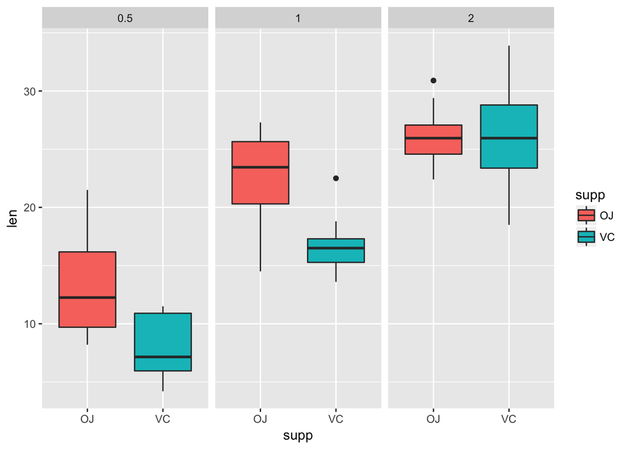

```r
ggplot(ToothGrowth, aes(x = supp, y = len)) +
      geom_boxplot(aes(fill = supp)) +
      facet_wrap(~dose)
```

Looking at information from the exploratory data analysis, there are two key observations: 1) higher doses produce greater tooth growth; and 2) ‘OJ’ produces tooth growth equal to or better than ‘VC’ at all observed dose levels, particularly at lower doses. As there are 10 observations for each supp-dose combination, we will use T-statistics to evaluate whether ‘OJ’ results are significantly better th ‘VC’ and whether dose levels produce materially different growth.

## Confidence Intervals & Hypothosis Testing

As previously stated, there are two variables of interest, supplement(‘VC’, ‘OJ’) and dose(0.5, 1.0, and 2.0). Our initial testing will be to look at the supplement. There may be two questions to be answered here. First, does ‘OJ’ promote greater tooth growth than ‘VC’? This would be across all dosing levels. Once we answer this question, we may want to evaluate the supplement within each dosing level.

### T-test: Difference in Tooth Growth by Supplement

```r
vc_ttl <- select(subset(ToothGrowth, supp == "VC"), supp, len)
oj_ttl <- select(subset(ToothGrowth, supp == "OJ"), supp, len)

t.test(oj_ttl$len,vc_ttl$len, paired = FALSE, var.equal = FALSE, alternative = "greater")
```

```
##
##  Welch Two Sample t-test
##
## data:  oj_ttl$len and vc_ttl$len
## t = 1.9153, df = 55.309, p-value = 0.03032
## alternative hypothesis: true difference in means is greater than 0
## 95 percent confidence interval:
##  0.4682687       Inf
## sample estimates:
## mean of x mean of y
##  20.66333  16.96333
```

The t.test results in a p-value = 0.03032. As this is less than our target $\alpha =$ 0.05, we reject the NULL hypothesis that there is no significant difference in favor of the alternative hypothesis, $H_a$, that ‘OJ’ promotes greater tooth growth than the supplement ‘VC’.

### T-test: Difference in Tooth Growth by Supplement with a dose level

We are focus on the difference in tooth growth produced by a supplement and dose level. Before applying t.test(), we will subset data to reflect ths specified populations. We will create 6 data subsets, each represent a specific supp and dose. For example, vc05 represents data for the supp ‘VC’ at a 0.5 dose level. Similarly, oj10 reprsents data for the supp ‘OJ’ and dose level of 1.0.

##### T-test: Greater Tooth Growth with the supplement ‘OJ’ versus ‘VC’ at dose = 0.5

```r
vc05 <- select(subset(ToothGrowth, supp == "VC" & dose == 0.5), supp, len)
vc10 <- select(subset(ToothGrowth, supp == "VC" & dose == 1.0), supp, len)
vc20 <- select(subset(ToothGrowth, supp == "VC" & dose == 2.0), supp, len)
oj05 <- select(subset(ToothGrowth, supp == "OJ" & dose == 0.5), supp, len)
oj10 <- select(subset(ToothGrowth, supp == "OJ" & dose == 1.0), supp, len)
oj20 <- select(subset(ToothGrowth, supp == "OJ" & dose == 2.0), supp, len)

t.test(oj05$len,vc05$len, paired = FALSE, var.equal = FALSE, alternative = "greater")
```

```
##
##  Welch Two Sample t-test
##
## data:  oj05$len and vc05$len
## t = 3.1697, df = 14.969, p-value = 0.003179
## alternative hypothesis: true difference in means is greater than 0
## 95 percent confidence interval:
##  2.34604     Inf
## sample estimates:
## mean of x mean of y
##     13.23      7.98
```

We are testing whether we would reject the NULL hypothesis that tooth growth for ‘VC’ and ‘OJ’ are similar at a dose = 0.5. The alternative hypothesis, $H_a$, is that ‘OJ’ promotes greater tooth growth at dose = 0.5. Performing a t-test we obtained a p-value = 0.003179. This is less than our target $\alpha =$ 0.05 so we reject the NULL hypothesis in favor of the alternative hypothesis, supp ‘OJ’ promotes greater tooth growth than ‘VC’ at a dose = 0.05.

##### T-test: Greater Tooth Growth with the supplement ‘OJ’ versus ‘VC’ at dose = 1.0

```r
t.test(oj10$len,vc10$len, paired = FALSE, var.equal = FALSE, alternative = "greater")
```

```
##
##  Welch Two Sample t-test
##
## data:  oj10$len and vc10$len
## t = 4.0328, df = 15.358, p-value = 0.0005192
## alternative hypothesis: true difference in means is greater than 0
## 95 percent confidence interval:
##  3.356158      Inf
## sample estimates:
## mean of x mean of y
##     22.70     16.77
```

##### T-test: Difference in Tooth Growth by Supplement with dose = 2.0

```r
t.test(oj20$len,vc20$len, paired = FALSE, var.equal = FALSE, alternative = "greater")
```

```
##
##  Welch Two Sample t-test
##
## data:  oj20$len and vc20$len
## t = -0.046136, df = 14.04, p-value = 0.5181
## alternative hypothesis: true difference in means is greater than 0
## 95 percent confidence interval:
##  -3.1335     Inf
## sample estimates:
## mean of x mean of y
##     26.06     26.14
```

Our final t.test, comparing tooth growth for supplements ‘OJ’ and ‘VC’, reflects a dose = 2.0. If you recall, the boxplot might suggest that there is no significant different in the mean tooth growth for the two supplements. The t.test, p-value = 0.5181 is rather larger, well above the threshold $\alpha =$ 0.05. We accept the NULL hypothesis which is consistent with what we expected by looking at our boxplot.

### T-test: Difference in Tooth Growth due to dose

##### Tooth Growth: Supp (‘OJ’) by comparing dose [0.5, 2.0]

```r
t.test(oj20$len,oj05$len, paired = FALSE, var.equal = FALSE, alternative = "greater")
```

```
##
##  Welch Two Sample t-test
##
## data:  oj20$len and oj05$len
## t = 7.817, df = 14.668, p-value = 6.619e-07
## alternative hypothesis: true difference in means is greater than 0
## 95 percent confidence interval:
##  9.94845     Inf
## sample estimates:
## mean of x mean of y
##     26.06     13.23
```

In this test, we seek to evaluate whether, for the supplement ‘OJ’, a dose = 2.0 promotes greater tooth growth than a dose = 0.05. Base on t.test p-value = 6.619e-07 (0.0000006619), very small, we reject the NULL hypothesis that there is no difference in tooth growth between the dose levels, 0.5 & 2.0. In other words, the t.test results suggest that there is greater tooth growth with a dose = 2.0 versus a dose = 0.5.

##### Tooth Growth: Supp (‘VC’) by comparing dose [0.5, 2.0]

```r
t.test(vc20$len,vc05$len, paired = FALSE, var.equal = FALSE, alternative = "greater")
```

```
##
##  Welch Two Sample t-test
##
## data:  vc20$len and vc05$len
## t = 10.388, df = 14.327, p-value = 2.341e-08
## alternative hypothesis: true difference in means is greater than 0
## 95 percent confidence interval:
##  15.08583      Inf
## sample estimates:
## mean of x mean of y
##     26.14      7.98
```

#### Tooth Growth: Significant for interim dose levels

Although it appears to be clear that there is greater tooth growth for a higher dose, 2.0 versus 0.5, of either supplement, ‘VC’ and ‘OJ’, we wish to determine whether tooth growth is greater for interim dose levels (e.g. dose = 1.0 versus dose = 0.5 and does = 2.0 versus dose = 1.0).

##### Tooth Growth: Supp (‘OJ’) by comparing interim dose [1.0 versus 0.5]

```r
t.test(oj10$len,oj05$len, paired = FALSE, var.equal = FALSE, alternative = "greater")
```

```
##
##  Welch Two Sample t-test
##
## data:  oj10$len and oj05$len
## t = 5.0486, df = 17.698, p-value = 4.392e-05
## alternative hypothesis: true difference in means is greater than 0
## 95 percent confidence interval:
##  6.214316      Inf
## sample estimates:
## mean of x mean of y
##     22.70     13.23
```

##### Tooth Growth: Supp (‘OJ’) by comparing interim dose [2.0 versus 1.0]

```r
t.test(oj20$len,oj10$len, paired = FALSE, var.equal = FALSE, alternative = "greater")
```

```
##
##  Welch Two Sample t-test
##
## data:  oj20$len and oj10$len
## t = 2.2478, df = 15.842, p-value = 0.0196
## alternative hypothesis: true difference in means is greater than 0
## 95 percent confidence interval:
##  0.7486236       Inf
## sample estimates:
## mean of x mean of y
##     26.06     22.70
```

For the supplement ‘OJ’, the p-value for each of the interim dose increases are below our threshold of $\alpha =$ 0.05, 4.392e-05 (0.00004392) and 0.0196, respectively. We reject the NULL hypothesis for both incremental dose levels. Tooth growth associated with the higher dose of the supplement ‘OJ’ is greater than the lower dose of the supplement ‘OJ’.

##### Tooth Growth: Supp (‘VC’) by comparing interim dose [1.0 versus 0.5]

```r
t.test(vc10$len,vc05$len, paired = FALSE, var.equal = FALSE, alternative = "greater")
```

```
##
##  Welch Two Sample t-test
##
## data:  vc10$len and vc05$len
## t = 7.4634, df = 17.862, p-value = 3.406e-07
## alternative hypothesis: true difference in means is greater than 0
## 95 percent confidence interval:
##  6.746867      Inf
## sample estimates:
## mean of x mean of y
##     16.77      7.98
```

##### Tooth Growth: Supp (‘VC’) by comparing interim dose [2.0 versus 1.0]

```r
t.test(vc20$len,vc10$len, paired = FALSE, var.equal = FALSE, alternative = "greater")
```

```
##
##  Welch Two Sample t-test
##
## data:  vc20$len and vc10$len
## t = 5.4698, df = 13.6, p-value = 4.578e-05
## alternative hypothesis: true difference in means is greater than 0
## 95 percent confidence interval:
##  6.346525      Inf
## sample estimates:
## mean of x mean of y
##     26.14     16.77
```

For the supplement ‘VC’, similar to results for the supplement ‘OJ’, the p-value for each of the interim dose increases are below our threshold of $\alpha =$ 0.05, 3.406e-07 (0.0000003406) and 4.578e-05 (0.00004578), respectively. We reject the NULL hypothesis for both incremental dose levels. Tooth growth associated with the higher dose of the supplement ‘VC’ is greater than the lower dose of the supplement ‘VC’.

## Conclusion

Following our review of Exploratory Data Analysis, it was decided to test two assumptions. From the boxplot, it appeared that the supplement ‘OJ’ promoted greater tooth growth than the supplement ‘VC’. It was also apparent that a higher dose promoted greater tooth growth, regardless of supplement introduced. We chose to test these assumptions by setting NULL hypothesis that there was no difference in the tooth growth for supplement ‘OJ’ versus ‘VC’ and a higher dose versus lower dose. The alternative hypothesis being that ‘OJ’ promotes greater tooth growth than ‘VC’ and a higher dose promotes greater tooth growth than a lower dose.

From our t.test, the p-values were rather small, with the exception of testing whether ‘OJ’ promotes greater tooth growth than ‘VC’ at a dose = 2.0, indicating that we reject the NULL hypothesis. In summary, the analysis suggests that ‘OJ’ promotes greater tooth growth than ‘VC’. Additionally, regardless of the supplement selected, ‘OJ’ or ‘VC’, a higher dose of the supplement promotes greater tooth growth than lower dose.